# Exercise 5 of “Big Data Analytics” (Winter Semester 2020/21)

# Task 2: Clustering

## a) Visualization

According to `help(faithful)`, the dataset contains eruptions and waiting times of the [geyser Old Faithful](https://en.wikipedia.org/wiki/Old_Faithful).

```r
summary(faithful)
```

```
   eruptions        waiting
 Min.   :1.600   Min.   :43.0
 1st Qu.:2.163   1st Qu.:58.0
 Median :4.000   Median :76.0
 Mean   :3.488   Mean   :70.9
 3rd Qu.:4.454   3rd Qu.:82.0
 Max.   :5.100   Max.   :96.0
```

Clustering algorithms are usually based on distance computations. If attributes are scaled differently, distance computations are biased towards the attributes with the bigger ranges. We noted a similar phenomenon for PCA. Thus, we should normalize the data:

```r
dataset <- data.frame(scale(faithful))
```

Now we plot the data:

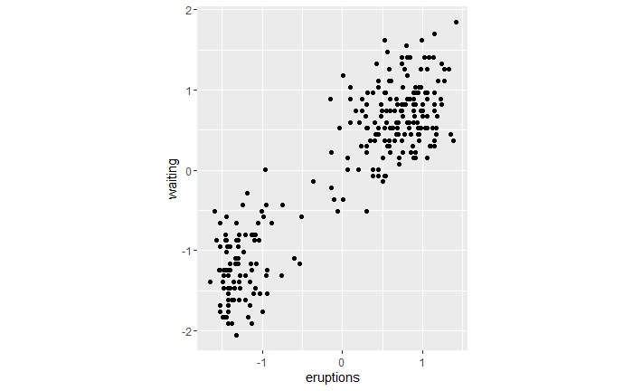

```r
library(ggplot2)
ggplot(data = dataset) +
  geom_point(mapping = aes(x = eruptions, y = waiting)) +
  coord_fixed() # uniform axis scaling
```

Looks like there are two roughly spherical (or elliptical) clusters. This is a comparatively easy situation for many standard clustering algorithms.

## b) Partitioning Clustering & c) Silhouette Coefficient

To avoid repetition of code, we combine sub-tasks b) and c). Before we systematically evaluate different values of $k$, we first see how clustering and silhouette computation work:

```r
kmeansResult <- kmeans(dataset, centers = 2, nstart = 5)
str(kmeansResult)
```

```
List of 9
 $ cluster     : Named int [1:272] 2 1 2 1 2 1 2 2 1 2 ...
  ..- attr(*, "names")= chr [1:272] "1" "2" "3" "4" ...
 $ centers     : num [1:2, 1:2] -1.258 0.708 -1.199 0.675
  ..- attr(*, "dimnames")=List of 2
  .. ..$ : chr [1:2] "1" "2"
  .. ..$ : chr [1:2] "eruptions" "waiting"
 $ totss       : num 542
 $ withinss    : num [1:2] 24.9 54.4
 $ tot.withinss: num 79.3
 $ betweenss   : num 463
 $ size        : int [1:2] 98 174
 $ iter        : int 1
 $ ifault      : int 0
 - attr(*, "class")= chr "kmeans"
```

We don’t need to load a package for `kmeans()`. It’s part of the standard package `stats`. We use the parameter `nstart`, because k-means depends on the initialization of its centroids. Repeating (re-starting) the procedure multiple times makes the result more stable. For guaranteed reproducibility, we could initialize the random-number generator with `set.seed()`.

The result object stores cluster assignments, cluster centers, and some statistics. “ss” means “sum of squares”. The objective of k-means is minimizing the sum of squared Euclidean distances of points to their corresponding cluster centers.

Let’s compute the silhouette coefficient:

```r
distObject <- dist(dataset)
silhResult <- cluster::silhouette(x = kmeansResult$cluster, dist = distObject)
str(silhResult)
```

```
 'silhouette' num [1:272, 1:3] 2 1 2 1 2 1 2 2 1 2 ...
 - attr(*, "dimnames")=List of 2
  ..$ : NULL
  ..$ : chr [1:3] "cluster" "neighbor" "sil_width"
 - attr(*, "Ordered")= logi FALSE
 - attr(*, "call")= language silhouette.default(x = kmeansResult$cluster, dist = distObject)
```

```r
summary(silhResult)
```

```
Silhouette of 272 units in 2 clusters from silhouette.default(x = kmeansResult$cluster, dist = distObject) :
 Cluster sizes and average silhouette widths:
       98       174
0.7638492 0.7346612
Individual silhouette widths:
    Min.  1st Qu.   Median     Mean  3rd Qu.     Max.
0.002664 0.734808 0.783837 0.745177 0.814130 0.844247
```

The silhouette coefficient does not only depend on cluster assignments, but also distances between points. The `dist()` function computes a distance matrix (though it is stored as one-dimensional `dist` object). Multiple distance measures are supported, the default is the Euclidean distance. We can see that the silhouette function does not return an overall silhouette value, but one for each point. In contrast, the `summary()` function also provides aggregates. We can also simply compute the mean on our own:

```r
mean(silhResult[, "sil_width"])
```

```
[1] 0.7451774
```

Furthermore, there is a built-in plot functionality:

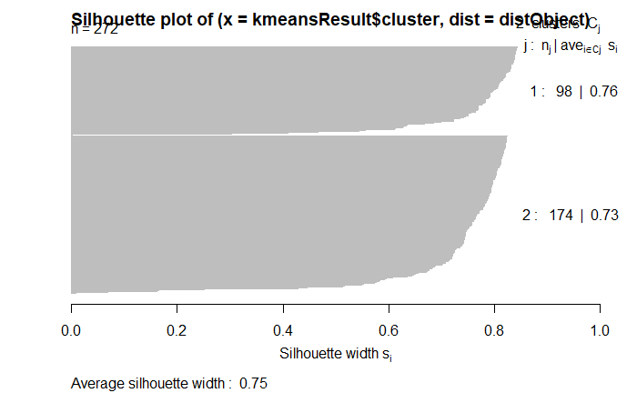

```r
plot(silhResult, border = NA)
```

Now, for evaluating different values of $k$, we use a loop to:

- conduct clustering
- compute the silhouette coefficient
- plot the clustering result

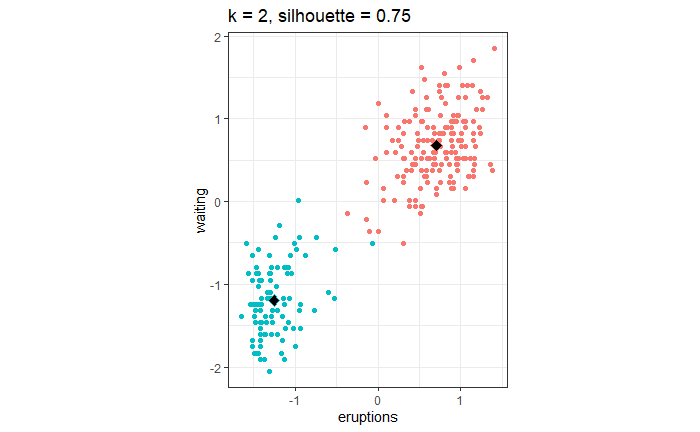

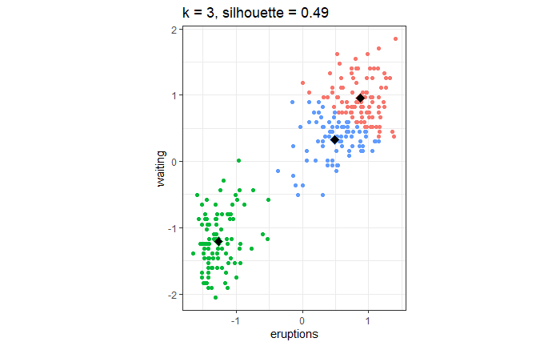

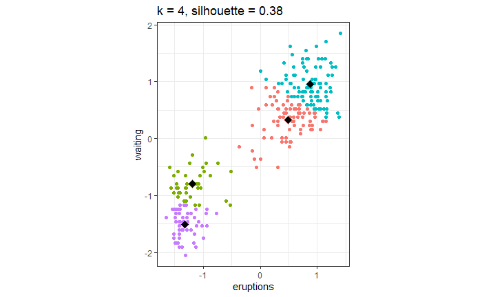

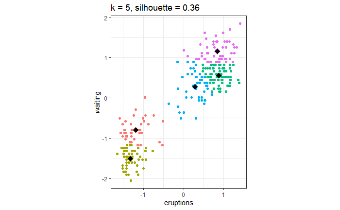

```r
kValues <- 2:5
distObject <- dist(dataset)
for (k in kValues) {
  kmeansResult <- kmeans(dataset, centers = k, nstart = 5)
  silhResult <- cluster::silhouette(x = kmeansResult$cluster, dist = distObject)
  clusterAssignmentData <- cbind(dataset, cluster = as.factor(kmeansResult$cluster))
  clusterCenterData <- cbind(data.frame(kmeansResult$centers), cluster = as.factor(1:k))
  print(
    ggplot(mapping = aes(x = eruptions, y = waiting, col = cluster)) +
      geom_point(data = clusterAssignmentData) +
      geom_point(data = clusterCenterData, shape = 23, size = 3, fill = "black") +
      theme_bw() + # black-and-white theme
      theme(legend.position = "none") + # disable legend
      coord_fixed() + # uniform axis scaling
      ggtitle(paste0("k = ", k, ", silhouette = ", round(mean(silhResult[, "sil_width"]), digits = 2)))
  )
}
```

To display results from within loops, we need to call the `print()` function explicitly. Also, note that we can plot different datasets in one plot (i.e., there are two calls to `geom_point()`): Here, we plot the original points as well as the cluster centers.

As we assumed, using two clusters yields the most intuitive results on the plots. One might object against outlier points (e.g., those in the middle between the clusters) being also assigned to clusters, but most clustering algorithms do that.

Computationally, two clusters result in the highest value of the silhouette coefficient. Thus, silhouette coefficient, and also other measures for cluster quality, can help to determine parameters of clustering algorithms. Of course, this assumes the clustering quality measure is aligned to the objective of the clustering algorithm. In that regard, silhouette coefficient and k-means are a suitable combination.

With higher k, the existing clusters are split up into roughly spherical, roughly equal-sized clusters. This is related to the objective function of k-means. Thus, if clusters have a different shape, then k-means is not suitable.

## d) Hierarchical Clustering

For hierarchical clustering, we need to pass a `dist` object. This has the advantage that we can swap the distance metric, which isn’t possible for k-means.

```r
hclustResult <- hclust(d = dist(dataset), method = "single")
str(hclustResult)
```

```
List of 7
 $ merge      : int [1:271, 1:2] -11 -14 -26 -38 -72 -93 -104 -135 -138 -141 ...
 $ height     : num [1:271] 0 0 0 0 0 0 0 0 0 0 ...
 $ order      : int [1:272] 47 149 24 215 174 33 165 46 3 170 ...
 $ labels     : chr [1:272] "1" "2" "3" "4" ...
 $ method     : chr "single"
 $ call       : language hclust(d = dist(dataset), method = "single")
 $ dist.method: chr "euclidean"
 - attr(*, "class")= chr "hclust"
```

The result object represents the dendrogram in numerical form. Thus, it also allows to determine in which order clusters should be merged to get cluster assignments. The parameter `method` describes the linkage criterion, i.e., how should the distance between clusters be computed: Average distance between data objects, minimum/maximum distance between data objects etc. This can have a great effect on clustering results. For example, with “single” (minimum), a small chain of points between otherwise well-defined clusters can result in their merge. In our dataset, which is rather well behaving, the choice of `method` does not have a big impact.

We can directly plot the results to get a dendrogram, though the default plot is quite ugly:

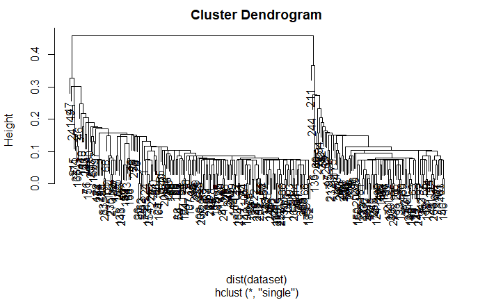

```r
plot(hclustResult)
```

To get fixed cluster assignments, we need to cut the dendrogram at a certain height. Fortunately, we can use the function `cutree()`, where we just specify the target number of clusters:

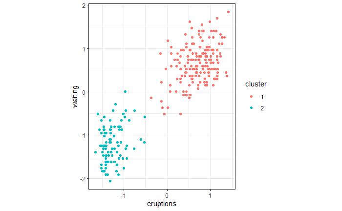

```r
clusterAssignments <- as.factor(cutree(hclustResult, k = 2))
ggplot(data = cbind(dataset, cluster = clusterAssignments)) +
  geom_point(mapping = aes(x = eruptions, y = waiting, col = cluster)) +
  theme_bw() +
  coord_fixed() # uniform axis scaling
```

The result looks good and is quite similar to k-means, comparing the plots. This might be related to the simplicity of the dataset, making it easy for different clustering algorithms to yield a similar result. For other datasets, results between clustering algorithms might vary more.

As a side-note: Though we just made a visual comparison to k-means, there are also formal measures to compare clusterings. These are so-called external validity indices. In contrast, the silhouette coefficient is an internal validity index, as it evaluates one clustering.

By the way, the hierarchical clustering obtained above was agglomerative (bottom-up). `cluster::diana()` provides a divisive (top-down) approach.

## e) Density-based Clustering (1)

Let’s start DBSCAN with some random parameter values right away:

```r
library(dbscan)
dbscanResult <- dbscan(x = dataset, eps = 0.1, minPts = 5)
dbscanResult
```

```
DBSCAN clustering for 272 objects.
Parameters: eps = 0.1, minPts = 5
The clustering contains 8 cluster(s) and 126 noise points.

  0   1   2   3   4   5   6   7   8
126  42  71   6   7   6   6   4   4

Available fields: cluster, eps, minPts
```

```r
str(dbscanResult)
```

```
List of 3
 $ cluster: int [1:272] 0 1 0 0 2 0 0 0 1 0 ...
 $ eps    : num 0.1
 $ minPts : num 5
 - attr(*, "class")= chr [1:2] "dbscan_fast" "dbscan"
```

Running DBSCAN is equally simple as other clustering techniques. However, choosing its parameters, in particular `eps`, is quite tricky. For example, here we have produced a lot of noise points.

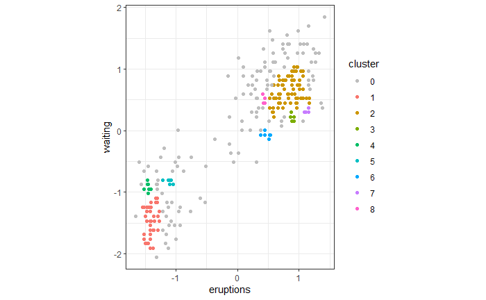

```r
ggplot(data = cbind(dataset, cluster = as.factor(dbscanResult$cluster))) +
  geom_point(mapping = aes(x = eruptions, y = waiting, col = cluster)) +
  theme_bw() +
  coord_fixed() + # uniform axis scaling
  scale_color_manual(values = c("gray", scales::hue_pal()(max(dbscanResult$cluster))))
```

The call to `scale_color_manual()` might look a bit strange, but what we are basically doing is using gray for the noise cluster and the default `ggplot2` colors for the rest. In our plot, we see the high amount of noise points. Also, the true clusters are split up into multiple sub-clusters, due to our density settings.

In general, the silhouette coefficient is not a good measure for density-based clustering. As we noted before, silhouette considers distances within clusters and between clusters. In contrast, density-based clustering finds clusters of arbitrary shape, as long as they meet the density requirements. However, in our case, we know that the silhouette coefficient is able to describe the true clusters in the data quite well. Thus, we can use silhouette to search for a good parametrization of DBSCAN:

```r
bestEps <- NA
bestMinPts <- NA
bestSil <- -Inf
distObject <- dist(dataset)
for (eps in 0.01 * 2^(1:20)) {
  for (minPts in 1:10) {
    dbscanResult <- dbscan(x = dataset, eps = eps, minPts = minPts)
    if (!all(dbscanResult$cluster == dbscanResult$cluster[1])) {
      silObject <- cluster::silhouette(x = dbscanResult$cluster, dist = distObject)
      sil <- mean(silObject[, "sil_width"])
      if (sil > bestSil) {
        bestSil <- sil
        bestEps <- eps
        bestMinPts <- minPts
      }
    }
  }
}
```

The approach we use is called grid search: We define a range of interesting values for each hyper-parameter and then search over all combinations. We use a linear range for `minPts` and an exponential range for `eps`. Here, we treat all noise points as belonging to the same cluster. As widespread noise clusters will result in bad silhouette values, we thereby hope to reduce the number of noise points altogether. We also need to handle the case that the silhouette is undefined, which happens if all points are in one cluster (may it be noise, may it be a regular cluster). We just ignore these cases.

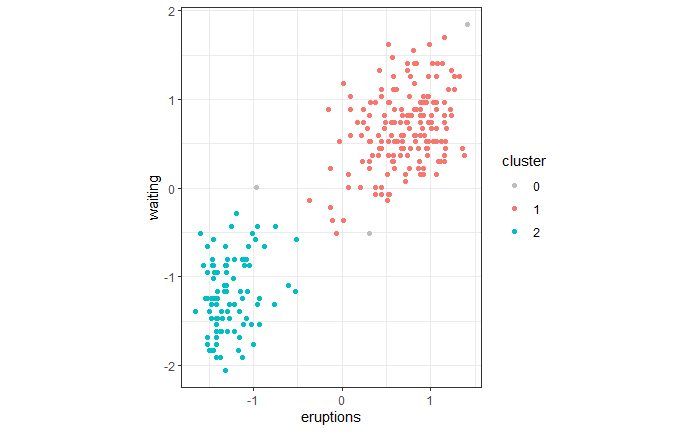

```r
dbscanResult <- dbscan(x = dataset, eps = bestEps, minPts = bestMinPts)
ggplot(data = cbind(dataset, cluster = as.factor(dbscanResult$cluster))) +
  geom_point(mapping = aes(x = eruptions, y = waiting, col = cluster)) +
  theme_bw() +
  coord_fixed() + # uniform axis scaling
  scale_color_manual(values = c("gray", scales::hue_pal()(max(dbscanResult$cluster))))
```

Quite good! We get two clusters and a few outlier points.

By the way, DBSCAN also has a built-in cluster plotting functionality:

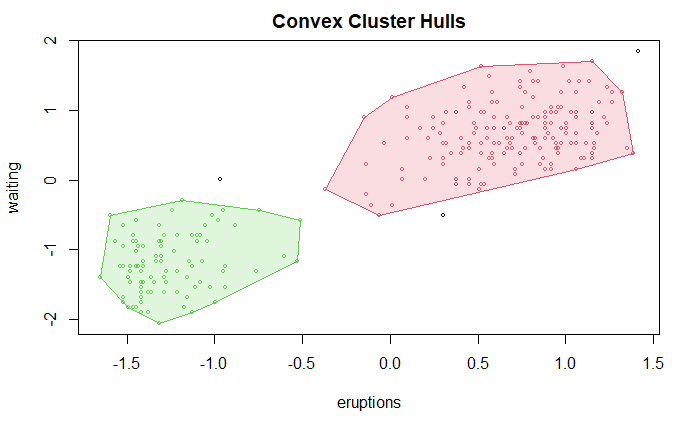

```r
hullplot(dataset, cl = dbscanResult$cluster)
```

And you can plot the distances to the nearest neighbors:

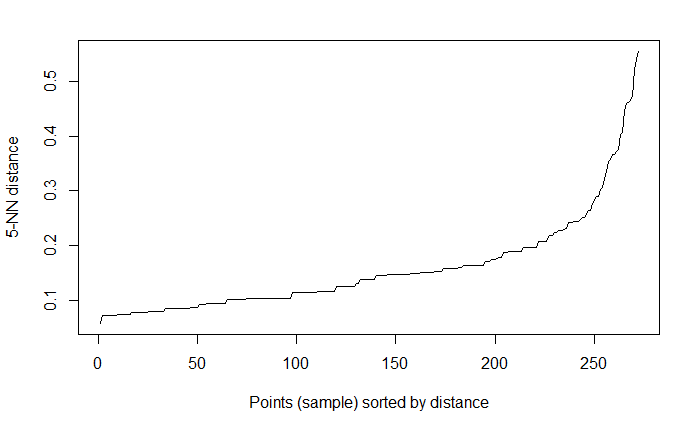

```r
kNNdistplot(x = dataset, k = 5)
```

This might be used to define the hyper-parameters. First, choose a value for `minPts`. Next, plot the distances to the `minPts` nearest neighbors. Distances where the graph suddenly increases might be good values for `eps`. However, this is a rather fuzzy definition.

## f) Density-based Clustering (2)

For OPTICS, we only need to specify `minPts`. We could also provide an upper bound for `eps` to speed up computation, but our dataset is small anyway. By default, the largest distance to a `minPts` neighbor is used.

```r
opticsResult <- optics(x = dataset, minPts = 5)
opticsResult
```

```
OPTICS ordering/clustering for 272 objects.
Parameters: minPts = 5, eps = 0.554951134410172, eps_cl = NA, xi = NA
Available fields: order, reachdist, coredist, predecessor, minPts, eps, eps_cl, xi
```

```r
str(opticsResult)
```

```
List of 8
 $ order      : int [1:272] 1 256 239 225 227 195 152 226 67 228 ...
 $ reachdist  : num [1:272] Inf 0.0438 0.2178 0.1499 0.079 ...
 $ coredist   : num [1:272] 0.2039 0.0438 0.3727 0.1535 0.079 ...
 $ predecessor: int [1:272] NA 237 253 167 262 121 130 80 99 62 ...
 $ minPts     : num 5
 $ eps        : num 0.555
 $ eps_cl     : logi NA
 $ xi         : logi NA
 - attr(*, "class")= chr "optics"
```

The results object is more complex than for DBSCAN, as it stores point order, reachability distances, core distances and the predecessors of the points. With that rich information, we can create a reachability plot:

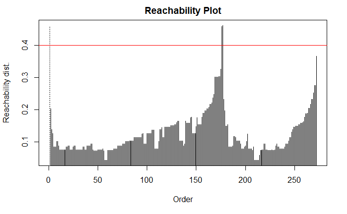

```r
plot(opticsResult)
abline(h = 0.4, col = "red")
```

This helps to determine a suitable `eps`. With a value of 0.4, we should get two large clusters, which are separated by a high reachability distance:

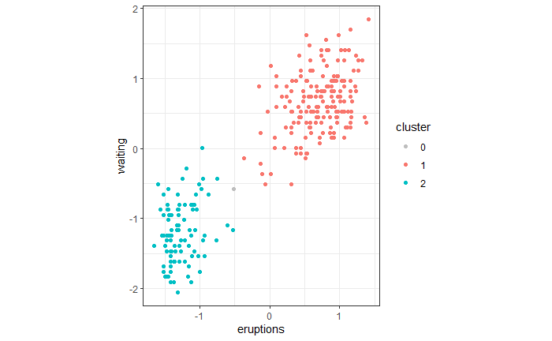

```r
dbscanResult <- extractDBSCAN(opticsResult, eps_cl = 0.4)
ggplot(data = cbind(dataset, cluster = as.factor(dbscanResult$cluster))) +
  geom_point(mapping = aes(x = eruptions, y = waiting, col = cluster)) +
  theme_bw() +
  coord_fixed() + # uniform axis scaling
  scale_color_manual(values = c("gray", scales::hue_pal()(max(dbscanResult$cluster))))
```

Well, that worked out as intended. So, by using OPTICS, we found a good value of `eps` for a given value of `minPts`. As we crossed two vertical bars in the plot, we actually have three clusters. One cluster does not contain enough points and thus is labeled as noise.

## g) Mixture Models

```r
library(mclust)
mclustResult <- Mclust(dataset, G = 1:10, verbose = FALSE)
str(mclustResult)
```

```
List of 16
 $ call          : language Mclust(data = dataset, G = 1:10, verbose = FALSE)
 $ data          : num [1:272, 1:2] 0.0983 -1.4787 -0.1356 -1.0556 0.9158 ...
  ..- attr(*, "dimnames")=List of 2
  .. ..$ : chr [1:272] "1" "2" "3" "4" ...
  .. ..$ : chr [1:2] "eruptions" "waiting"
 $ modelName     : chr "EEE"
 $ n             : int 272
 $ d             : int 2
 $ G             : int 3
 $ BIC           : 'mclustBIC' num [1:10, 1:14] -1559 -882 -865 -865 -850 ...
  ..- attr(*, "dimnames")=List of 2
  .. ..$ : chr [1:10] "1" "2" "3" "4" ...
  .. ..$ : chr [1:14] "EII" "VII" "EEI" "VEI" ...
  ..- attr(*, "G")= num [1:10] 1 2 3 4 5 6 7 8 9 10
  ..- attr(*, "modelNames")= chr [1:14] "EII" "VII" "EEI" "VEI" ...
  ..- attr(*, "control")=List of 4
  .. ..$ eps     : num 2.22e-16
  .. ..$ tol     : num [1:2] 1.00e-05 1.49e-08
  .. ..$ itmax   : int [1:2] 2147483647 2147483647
  .. ..$ equalPro: logi FALSE
  ..- attr(*, "initialization")=List of 3
  .. ..$ hcPairs: 'hc' num [1:2, 1:271] 183 264 132 183 132 222 132 268 132 175 ...
  .. .. ..- attr(*, "initialPartition")= num [1:272] 1 2 3 4 5 6 7 8 9 10 ...
  .. .. .. ..- attr(*, "unique")= int 272
  .. .. ..- attr(*, "dimensions")= int [1:2] 272 2
  .. .. ..- attr(*, "modelName")= chr "VVV"
  .. .. ..- attr(*, "call")= language hc(data = data, modelName = mclust.options("hcModelName")[1])
  .. .. ..- attr(*, "use")= chr "SVD"
  .. .. ..- attr(*, "data")= num [1:272, 1:2] -0.1031 0.404 -0.0137 0.2538 -0.2899 ...
  .. .. .. ..- attr(*, "dimnames")=List of 2
  .. .. .. .. ..$ : chr [1:272] "1" "2" "3" "4" ...
  .. .. .. .. ..$ : NULL
  .. ..$ subset : NULL
  .. ..$ noise  : NULL
  ..- attr(*, "warn")= logi FALSE
  ..- attr(*, "n")= int 272
  ..- attr(*, "d")= int 2
  ..- attr(*, "oneD")= logi FALSE
  ..- attr(*, "criterion")= chr "BIC"
```

[output cut: 26 more lines]

```
  .. .. .. ..$ : chr [1:2] "eruptions" "waiting"
  .. .. .. ..$ : chr [1:2] "eruptions" "waiting"
  .. ..$ cholSigma: num [1:2, 1:2] -0.245 0 -0.125 0.408
  .. .. ..- attr(*, "dimnames")=List of 2
  .. .. .. ..$ : chr [1:2] "eruptions" "waiting"
  .. .. .. ..$ : chr [1:2] "eruptions" "waiting"
 $ z             : num [1:272, 1:3] 9.72e-01 7.77e-13 9.97e-01 2.99e-07 1.17e-02 ...
  ..- attr(*, "dimnames")=List of 2
  .. ..$ : chr [1:272] "1" "2" "3" "4" ...
  .. ..$ : NULL
 $ classification: Named num [1:272] 1 2 1 2 3 2 3 1 2 3 ...
  ..- attr(*, "names")= chr [1:272] "1" "2" "3" "4" ...
 $ uncertainty   : Named num [1:272] 2.80e-02 7.77e-13 3.19e-03 2.99e-07 1.17e-02 ...
  ..- attr(*, "names")= chr [1:272] "1" "2" "3" "4" ...
 - attr(*, "class")= chr "Mclust"
```

WTF? Okay, this is a complex result. We have information about the original data, BIC values, final parameters, cluster assignments (`classification`) and more. Let’s have a look at the summary:

```r
summary(mclustResult)
```

```
----------------------------------------------------
Gaussian finite mixture model fitted by EM algorithm
----------------------------------------------------

Mclust EEE (ellipsoidal, equal volume, shape and orientation) model with 3 components:
```

|  | log-likelihood | n | df | BIC | ICL |
| --- | --- | --- | --- | --- | --- |
|  | -380.5144 | 272 | 11 | -822.6927 | -866.328 |

```
Clustering table:
  1   2   3
 41  97 134
```

Looks more useful. The algorithm decided on three clusters. Also, it chose a “ellipsoidal, equal volume, shape and orientation” model. This is related to the covariance matrix of the fitted distribution. For example, are clusters axis-parallel, do they have different size etc. For more details, you can read the article Scrucca (2016) “mclust 5: clustering, classification and density estimation using Gaussian finite mixture models.” The model stores its parameters, which are means and (co)variances:

```r
str(mclustResult$parameters)
```

```
List of 3
 $ pro     : num [1:3] 0.166 0.356 0.477
 $ mean    : num [1:2, 1:3] 0.268 0.485 -1.271 -1.207 0.855 ...
  ..- attr(*, "dimnames")=List of 2
  .. ..$ : chr [1:2] "eruptions" "waiting"
  .. ..$ : NULL
 $ variance:List of 6
  ..$ modelName: chr "EEE"
  ..$ d        : int 2
  ..$ G        : int 3
  ..$ sigma    : num [1:2, 1:2, 1:3] 0.06 0.0306 0.0306 0.1824 0.06 ...
  .. ..- attr(*, "dimnames")=List of 3
  .. .. ..$ : chr [1:2] "eruptions" "waiting"
  .. .. ..$ : chr [1:2] "eruptions" "waiting"
  .. .. ..$ : NULL
  ..$ Sigma    : num [1:2, 1:2] 0.06 0.0306 0.0306 0.1824
  .. ..- attr(*, "dimnames")=List of 2
  .. .. ..$ : chr [1:2] "eruptions" "waiting"
  .. .. ..$ : chr [1:2] "eruptions" "waiting"
  ..$ cholSigma: num [1:2, 1:2] -0.245 0 -0.125 0.408
  .. ..- attr(*, "dimnames")=List of 2
  .. .. ..$ : chr [1:2] "eruptions" "waiting"
  .. .. ..$ : chr [1:2] "eruptions" "waiting"
```

You can also get information about the BIC used for selecting the model:

```r
summary(mclustResult$BIC)
```

```
Best BIC values:
             EEE,3       VEV,2      VEE,3
BIC      -822.6927 -828.569043 -830.38180
BIC diff    0.0000   -5.876374   -7.68913
```

Okay, enough complicated stuff for today. Let’s finish with a plot:

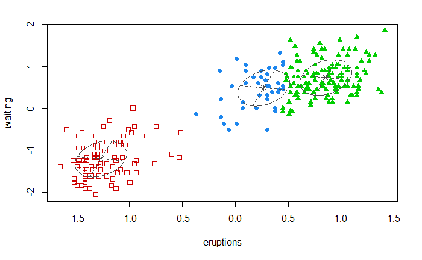

```r
plot(mclustResult, what = "classification")
```

Well, not optimal. In particular, one of our actual clusters in the data is bigger than the other, so `Mclust` choosing “equal volume” results in splitting up this cluster.

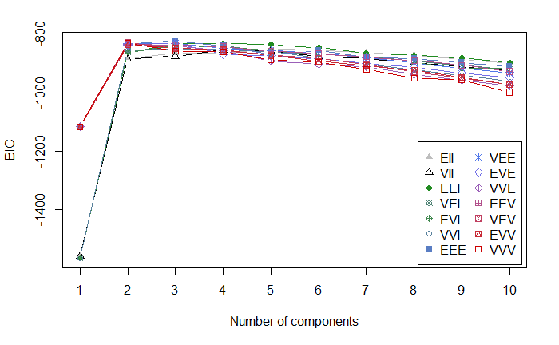

```r
plot(mclustResult, what = "BIC")
```

Apparently, it was a tough race between two and three components.